# IE 582 Homework 1

To compare better, I have plotted the old and new results together below:

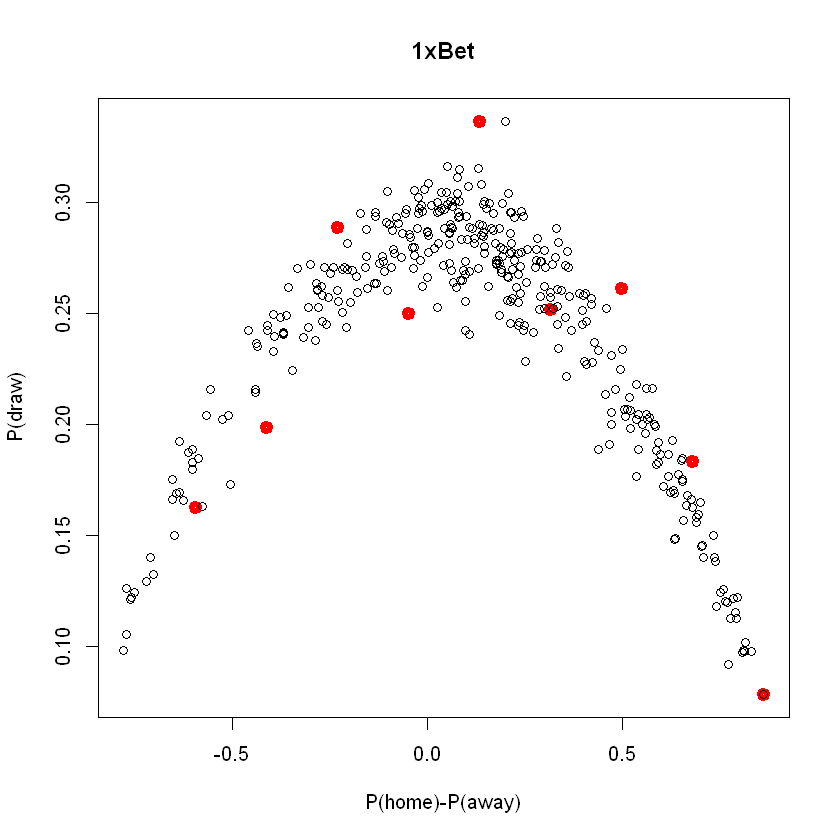

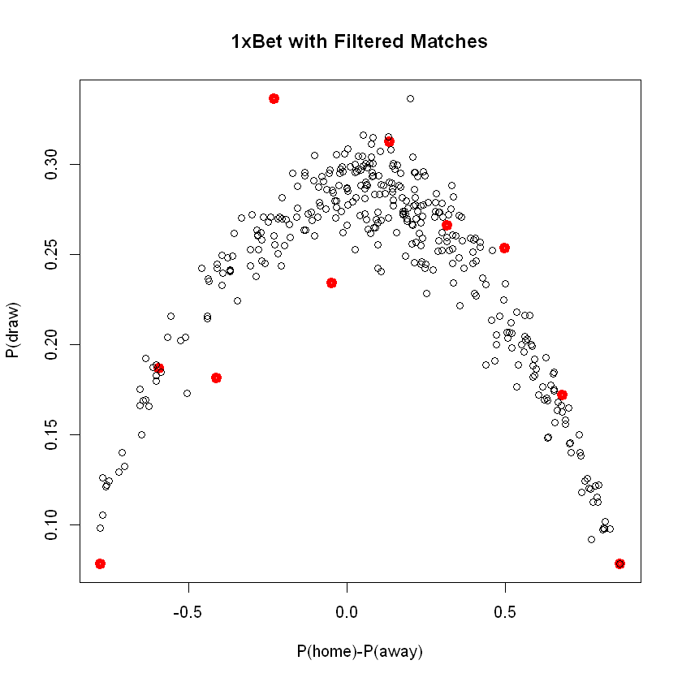

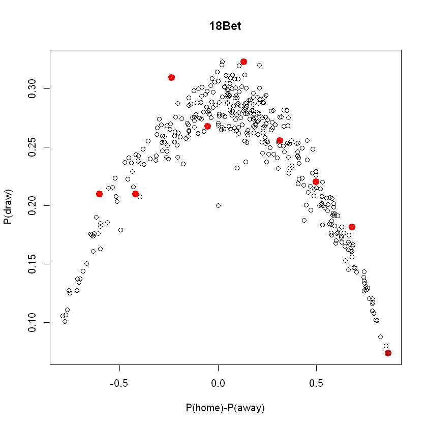

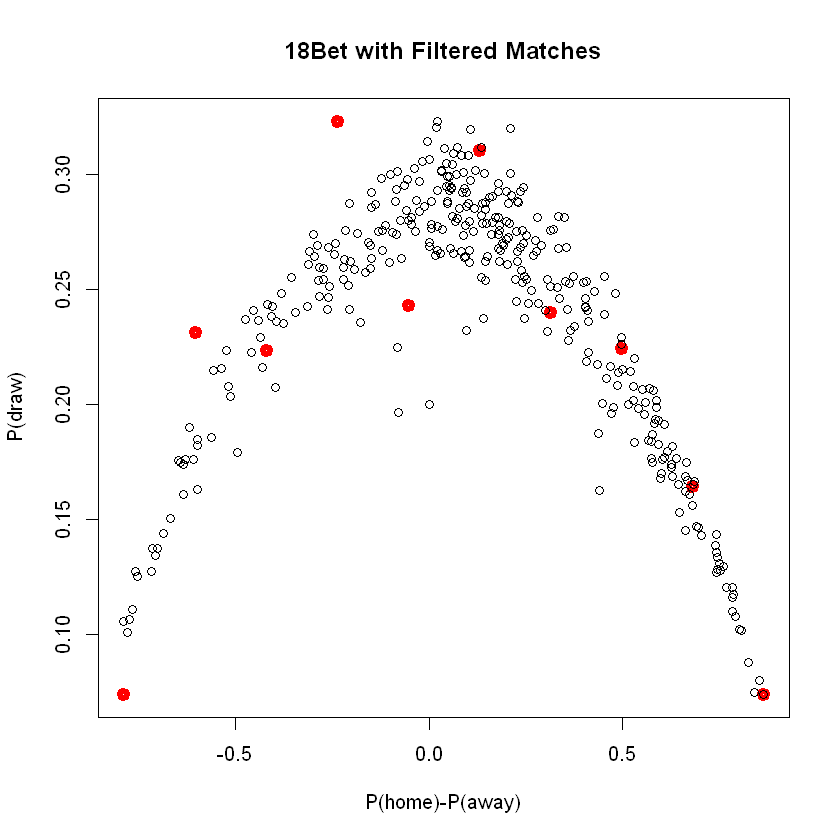

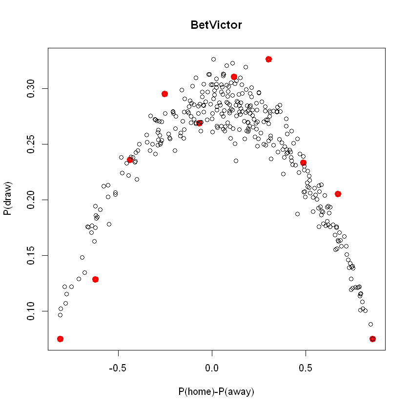

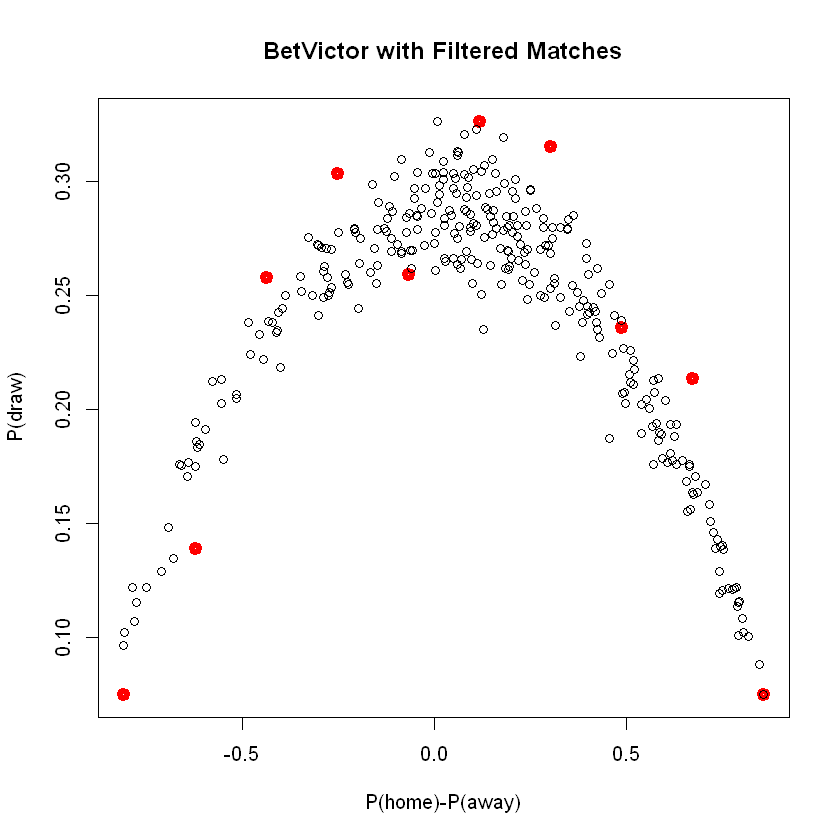

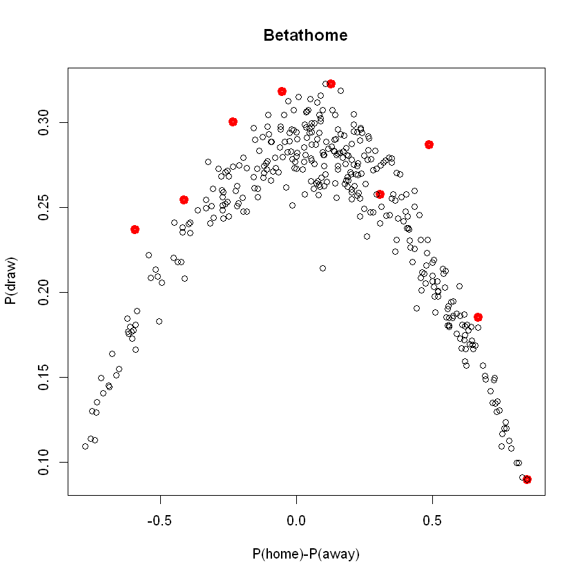

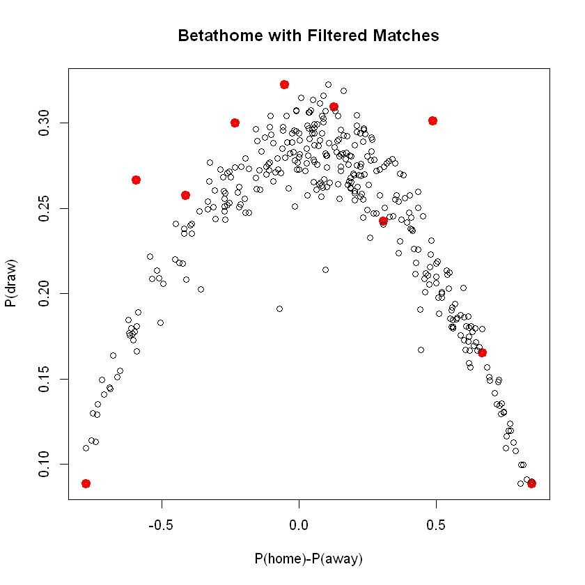

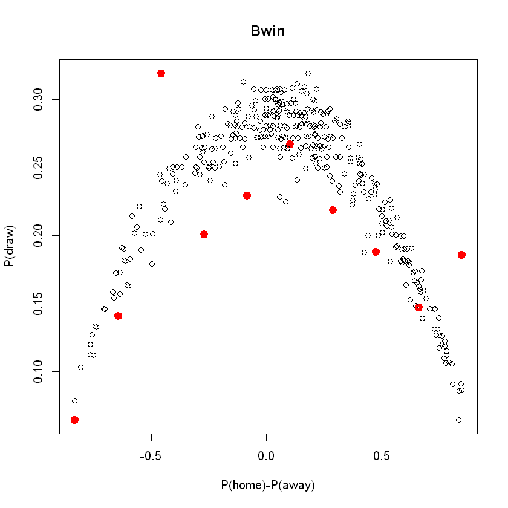

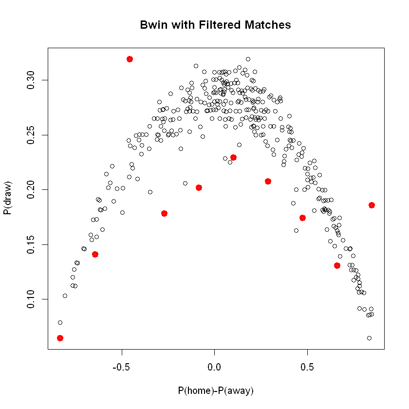

```r
plot(histdrawfinished_1xBet$counts/allhist_1xBet$counts, col = "red", lwd=5, xlab="", ylab="", axes=FALSE)
par(new=TRUE)
plot(p_homeminusaway_1xbet, draw_odd_bookmaker_1xBet$odds_prob, main="1xBet", xlab="P(home)-P(away)", ylab="P(draw)")

plot(histdrawfinished_1xBet2$counts/allhist_Bwin$counts, col = "red", lwd=5, xlab="", ylab="", axes=FALSE)
par(new=TRUE)
plot(p_homeminusaway_1xBet2, draw_odd_bookmaker_1xBet2$odds_prob, main="1xBet with Filtered Matches", xlab="P(home)-P(away)", ylab="P(draw)")

plot(histdrawfinished_18Bet$counts/allhist_18Bet$counts, col = "red", lwd=5, xlab="", ylab="", axes=FALSE)
par(new=TRUE)
plot(p_homeminusaway_18Bet, draw_odd_bookmaker_18Bet$odds_prob, main="18Bet", xlab="P(home)-P(away)", ylab="P(draw)")

plot(histdrawfinished_18Bet2$counts/allhist_Bwin$counts, col = "red", lwd=5, xlab="", ylab="", axes=FALSE)
par(new=TRUE)
plot(p_homeminusaway_18Bet2, draw_odd_bookmaker_18Bet2$odds_prob, main="18Bet with Filtered Matches", xlab="P(home)-P(away)", ylab="P(draw)")

plot(histdrawfinished_BetVictor$counts/allhist_BetVictor$counts, col = "red", lwd=5, xlab="", ylab="", axes=FALSE)
par(new=TRUE)
plot(p_homeminusaway_BetVictor, draw_odd_bookmaker_BetVictor$odds_prob, main="BetVictor", xlab="P(home)-P(away)", ylab="P(draw)")

plot(histdrawfinished_BetVictor2$counts/allhist_Bwin$counts, col = "red", lwd=5, xlab="", ylab="", axes=FALSE)
par(new=TRUE)
plot(p_homeminusaway_BetVictor2, draw_odd_bookmaker_BetVictor2$odds_prob, main="BetVictor with Filtered Matches", xlab="P(home)-P(away)", ylab="P(draw)")

plot(histdrawfinished_Betathome$counts/allhist_Betathome$counts, col = "red", lwd=5, xlab="", ylab="", axes=FALSE)
par(new=TRUE)
plot(p_homeminusaway_Betathome, draw_odd_bookmaker_Betathome$odds_prob, main="Betathome", xlab="P(home)-P(away)", ylab="P(draw)")

plot(histdrawfinished_Betathome2$counts/allhist_Bwin$counts, col = "red", lwd=5, xlab="", ylab="", axes=FALSE)
par(new=TRUE)
plot(p_homeminusaway_Betathome2, draw_odd_bookmaker_Betathome2$odds_prob, main="Betathome with Filtered Matches", xlab="P(home)-P(away)", ylab="P(draw)")

plot(histdrawfinished_Bwin$counts/allhist_Bwin$counts, col = "red", lwd=5, xlab="", ylab="", axes=FALSE)
par(new=TRUE)
plot(p_homeminusaway_Bwin, draw_odd_bookmaker_Bwin$odds_prob, main="Bwin", xlab="P(home)-P(away)", ylab="P(draw)")

plot(histdrawfinished_Bwin2$counts/allhist_Bwin$counts, col = "red", lwd=5, xlab="", ylab="", axes=FALSE)
par(new=TRUE)
plot(p_homeminusaway_Bwin2, draw_odd_bookmaker_Bwin2$odds_prob, main="Bwin with Filtered Matches", xlab="P(home)-P(away)", ylab="P(draw)")
```

Conclusions:

After filtering the extreme cases, the profit assumed when p(home) value is greater than p(away) has become less for bookmaker "1xBet". On the other hand, the new profit bin (-0.2,-0.4) has occured. The profit options also decreased in "18Bet" and "Bwin". On the other hand, long run winning options are increased for the bookmakers "BetVictor" and "Bet-at-home".